# lab

**Convex and Distributed Optimization Lab**  
**MSIAM — Université Grenoble Alpes — 2018/2019**  
**Lecturers: Jérôme Malick, Yassine Laguel, Sélim Chraibi**

**Author(s): Alanna Kennard**

```python
# Automatic reload of local libraries
%load_ext autoreload
%autoreload 2
%reload_ext autoreload
%matplotlib inline
```

> **I. Introduction**  
> **II. The optimization problem**  
> **III. Implementing the solvers**  
> GD (Gradient descent))  
> SGD (Stochastic Gradient Descent))  
> SAGA (Stochastic Average Gradient "Amélioré"))  
> SVRG (Stochastic Variance Reduced Gradient))  
> Comparison  
> **IV. Regularization**  
> **V. Further development**

In this lab, you will implement optimization algorithms that you've studied in class and use them to fit a logistic regression classification model.

You will be implementing a simplified version of [`sklearn.linear_model.LogisticRegression`](https://scikit-learn.org/stable/modules/generated/sklearn.linear_model.LogisticRegression.html).

Part of the work has already been done for you (see the `\lib` folder), so you'll only have to implement the `##### TODO (i) #####` sections of the code. Whenever you complete such a section, we ask you to **copy it in this notebook**. We want you to **only send us a pdf or html export of this notebook** so we won't be able to see your work if it's not in this notebook.

Report in groups of 1 to 3 students.  
**Due date:** Monday, January 6, 2019 (before midnight).  
**Send to:** cdo.grenoble@gmail.com

# I. Introduction

We consider the [Student Performance](http://archive.ics.uci.edu/ml/datasets/Student+Performance) dataset. This dataset contains student demographic, social, school-related features, how many classes they've missed, etc.

The goal we give ourselves is to predict whether a student will pass (final grade > 12).

We denote $A \in \mathcal{M}_{n,d}(\mathbb{R})$ the feature matrix, containing $n$ samples with $d$ features, and $b \in \{-1,1\}^n$ the label vector where $-1$ encodes `fail` and $1$ encodes `pass`.

The data has already been preprocessed (yay less work for you 🎉). You can check `\lib\datasets.py` if you're curious, otherwise, you can just use the following to load your dataset:

```python
from lib.datasets import load_student_data

A_train, A_test, b_train, b_test = load_student_data('data/student-mat.csv', split=0.25)
```

As mentioned previously, you're going to implement a simplified version of [`sklearn.linear_model.LogisticRegression`](https://scikit-learn.org/stable/modules/generated/sklearn.linear_model.LogisticRegression.html). So let's first see what the finished product should look like.

**Question:**

- Import [sklearn.linear_model.LogisticRegression](https://scikit-learn.org/stable/modules/generated/sklearn.linear_model.LogisticRegression.html) .
- Create an instance of sklearn's logistic regression classifiers with SAGA as its solver.
- Fit the classifier on the training data and compute the score of the fitted model on the test set.

```python
from sklearn.linear_model import LogisticRegression
lr= LogisticRegression(solver = 'saga', max_iter = 3000)
lr.fit(A_train, b_train)
y_pred = lr.predict(A_test)
```

[output not shown]

# II. The optimization problem

Logistic regression consists in finding the parameter $x \in \mathbb{R}^d$ that best fits: $$ b_i = \begin{cases} \phantom{-}1 \ \textrm{ if }\ \langle a_{i}, x\rangle \ge 0 \\ -1 \ \textrm{ if }\ \langle a_{i}, x\rangle < 0 \end{cases} $$ for all the samples $i$ of the training set (where $a_i$ is the $i^{th}$ line of $A$ and $b_i$ the $i^{th}$ element of $b$). To measure this fit, logistic regression chooses the following loss:

$$ \textrm{LogisticLoss}(b_i, \left\langle a_{i}, x\right\rangle ) = \log \left(1+\exp \left(-b_{i}\left\langle a_{i}, x\right\rangle\right)\right) $$

The corresponding optimization problem we will consider is the following:

Minimization of the empirical risk $f$ of the $L_2$-regularized logistic regression model, on the dataset $(A_{\textrm{train}},b_{\textrm{train}})$: $$ \begin{aligned} \textrm{min}_{x\in \mathbb{R}^d} \ f(x) \ &= \ \textrm{min}_{x\in \mathbb{R}^d} \ \frac{1}{n_{\textrm{train}}} \sum_{i=1}^{n_{\textrm{train}}} f_i(x) \\ &= \ \textrm{min}_{x\in \mathbb{R}^d}\frac{1}{n_{\textrm{train}}} \sum_{i=1}^{n_{\textrm{train}}} \textrm{LogisticLoss}(b_i, \left\langle a_{i}, x\right\rangle ) + \frac{l_2}{2}\|x\|^{2}_2, \end{aligned} $$ where $l_2 \ge 0$ is the $L_2$ regularization coefficient.

To simplify the notation, we'll stop indexing $A$, $b$ and $n$ with "$\textrm{train}$" in the following.

**Question:** $f$ is $\mu$-strongly convex.

- Give a lower bound on $\mu$.
- Complete **TODO (1)** in **\lib\linear_model.py**.

$f$ is $\mu$-strongly convex. Therefore $$ f(x)-\frac{\mu}{2}\|x\|^{2} $$ is convex $\forall x$.

As $ f(x) = L(x) + \frac{l_2}{2}\|x\|^{2}_2 $, $$\mu \geq l_2 $$

**Question:** Denote $\lambda_{\max}$ the largest eigenvalue of the real symmetric matrix $AA^T$.

- Prove that $\lambda_{\max}(\nabla^2 f_i) \le \lambda_{\max}(\frac{a_i a_i^T}{4} + l_2 I_d)$
- Prove that $\lambda_{\max}(a_i a_i^T) \le \|a_i\|^2_2$

Prove that $\lambda_{\max}(\nabla^2 f_i) \le \lambda_{\max}(\frac{a_i a_i^T}{4} + l_2 I_d)$

We can write $f_i(x) = l(x) + r(x)$, where $l(x)$ is the logistic loss function and $r(x)$ is the regularizer. Then $$ \nabla f_i(x) = \nabla l(b_i, \left\langle a_{i}, x\right\rangle ) + \nabla \frac{l_2}{2}\|x\|^{2}_2 $$ $$\Leftrightarrow \nabla f_i(x) = a_i \nabla l(b_i, \left\langle a_{i}, x\right\rangle ) + l_2 x$$ $$ \Leftrightarrow \nabla² f_i(x) = a_i a_i^T \nabla^2 l(b_i, \left\langle a_{i}, x\right\rangle ) + l_2 I_d$$

where $a_i a_i^T \in \mathbb{R}^{dxd}$, $l(b_i, \left\langle a_{i}, x\right\rangle )\text{ : } \mathbb{R}^d \rightarrow \mathbb{R}$.

As $x \in \mathbb{R}^d $, the hessian $\nabla^2 l(b_i, \left\langle a_{i}, x\right\rangle ) is \in \mathbb{R}^{dxd} $, and the jacobian of $x$, $J(x) = I_n\in \mathbb{R}^{dxd}$. Therefore the above expression is consistent

The largest eigenvalue is: $$ \lambda_{max}\left( \nabla² f_i(x) \right) = \lambda_{max}\left(a_i a_i^T \nabla^2 l(b_i, \left\langle a_{i}, x\right\rangle ) + l_2 I_d \right)$$

$$\nabla^2 l(b_i, \left\langle a_{i}, x\right\rangle ) = (-b_i \left\langle a_{i}, \mathbb{1}_d\right\rangle)^2 \frac{e^{-b_i \left\langle a_{i}, x \right\rangle}}{(1 + e^{-b_i \left\langle a_{i}, x\right\rangle})^2}$$

Let's make the substitutions $ y = e^{-b_i \left\langle a_{i}, x\right\rangle}$, $c = (-b_i \left\langle a_{i}, \mathbb{1}_d\right\rangle)^2$.

$$ \nabla^2 l(y) = c \frac{y}{(1+y)²}$$

In the limit as $y \rightarrow \infty $, $ \lim\limits_{y \to \infty} \frac{y}{(1+y)²} = \frac{1}{2(1+y)} $ by l'Hopital's rule. This function is monotone decreasing as $y \rightarrow \infty$. The function has a pole at $y = 1$ and reaches it's maximum as $y \rightarrow 1$

$$ \lim\limits_{y \to 1} \frac{1}{2 + 2y} = \frac{1}{4} $$

Therefore $\nabla^2 l(b_i, \left\langle a_{i}, x\right\rangle ) < 4 $, and $$ \lambda_{max}\left( \nabla² f_i(x) \right) \leq \lambda_{max}\left(\frac{a_i a_i^T}{4} + l_2 I_d \right)$$

Prove that $\lambda_{\max}(a_i a_i^T) \le \|a_i\|^2_2$ </li> Let $A = a_i a_i^T$. The Frobenius 2-norm of A can be expressed as: $$|| A ||_2 = \left( \sum_{i = 1}^{d} \sigma_i^2(A) \right)$$ $$ \left( \sum_{i = 1}^{d} \sigma_i^2(A) \right) \geq (\max\limits_{1 \leq i \leq d} \lambda_i(A) ^2)^{\frac{1}{2}} = \max\limits_{1 \leq i \leq d}(A) = \lambda_{max}(a_i a_i^T)$$ Now, $$||a_i ||_2^2 = \sum_{j = 1} ^ d |a_{i_j}|^2 \geq \max\limits_{i,j}||A_{i,j} ||_2 \geq \lambda_{max}(A)$$

A consequence of these results is that the $f_i$s and $f$ are all $L$-smooth with $L \le \frac{\max_i\|a_i\|^2_2}{4} + l_2$ and we can therefore use the following value in our implementation:

```
L = 0.25 * max(np.linalg.norm(A,2,axis=1))**2 + self.l2
```

# III. Implementing the solvers

To implement gradient methods, we need an oracle that will compute both batch gradients $\nabla f$ and partial gradients $\nabla f_i$.

**Question:** In the code below, $\nabla f$ has already been implemented.

- Complete **TODO (2)** bellow.
- Add your code to **\lib\linear_model.py**.

```python
def grad(x, i=None):
    '''
    Gradient of the objective function at x.
    If no i is given, grad should return the batch gradient.
    Otherwise, it should return the partial gradient associated the the datapoint (A[i], b[i]).
    '''

    if i is None: # return batch gradient
        output = -b/(1 + np.exp(b*np.dot(A, x)))
        output = sum(np.diag(output))/n @ A
        output += self.l2*x
    else: # return partial gradient associated the datapoint (A[i], b[i])
        output = -b[i] * (A[i]/( 1 + np.exp(b[i]*np.dot( A[i] , x ) ) ))
        output += self.l2 * x
    return output
```

# GD (Gradient descent)

At iteration k of the GD algorithm, the following update is executed:

$$ x_{k+1} \leftarrow x_{k} - \gamma\nabla f(x_k) $$

**Question:**

- What stepsize $\gamma$ ensures the convergence of this algorithm and under what assumptions?
- Complete **TODO (3)** and **TODO (4)**
- Add your code to **\lib\solvers.py**.

> **Answer:** $\gamma = \frac{1}{L}$, where L is a lower bound for the Lispchitz constant of any of the $f_i$'s and of $f$.

```python
def GD(x0, grad, prox, max_iter, n, L, mu):
    stepsize  = 1/L
    x         = x0
    x_tab     = np.copy(x)

    for k in range(max_iter):
        x     = x - stepsize*grad(x)
        x_tab = np.vstack((x_tab, x))

    return x, x_tab
```

**Question:** Run the code below to test your code.

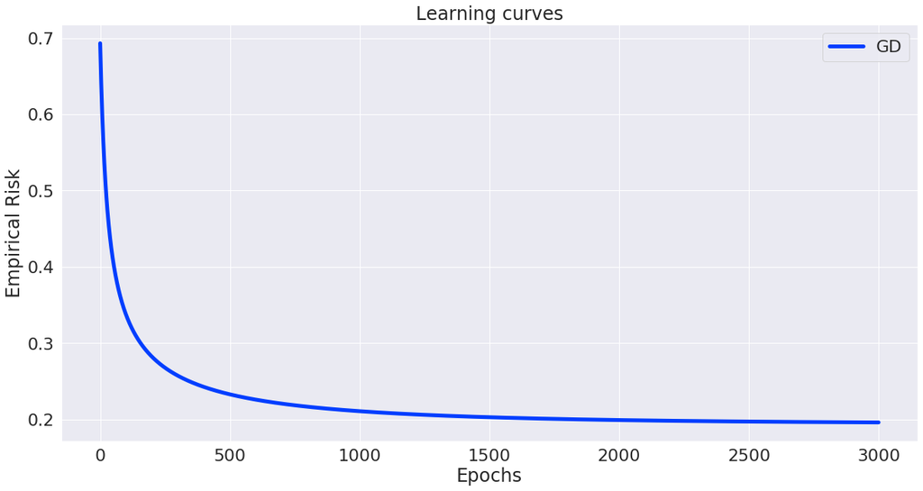

```python
from lib.linear_model import LogisticRegression
from lib.visuals import learning_curve

clf_gd = LogisticRegression(solver='gd', l2=0.01, max_iter=3000)
clf_gd.fit(A_train, b_train)

learning_curve(GD=clf_gd)
```

# SGD (Stochastic Gradient Descent)

Gradient descent works well for smooth convex problems. However, it is an expensive method as full gradients must be computed at each iteration and fails in the non convex setting as the gradient "gets stuck" in local minima.

For non convex or large scale learning problems, Stochastic Gradient Descent (SGD) may be more suitable. The SGD method is constructed from the hypothesis that if the function $f$ is L smooth, than the gradients $f_i$ of it's components are not too dissimilar from one another so that $\nabla f_i $ replaces $\nabla f$ in the descent iteration.

At iteration k of the SGD algorithm, the following update is executed:

$$ \begin{cases} i \textrm{ chosen randomly in } \{1...n\}\\ x_{k+1} \leftarrow x_{k} - \gamma_k \nabla f_i(x_k) \\ \end{cases} $$

**Question:**

- What stepsize $\gamma_k$ ensures the convergence of this algorithm and under what assumptions?
- Complete **TODO (5)**
- Add your code to **\lib\solvers.py**.

Due to the variance induced by random sampling, we need to choose $\gamma_k \leq \frac{1}{k}$, where k is the current iterate. Furthermore, $\gamma_k \leq \frac{1}{L}$ ensures a linear convergence. (Ref Accelerating SGD Using Predictive Variance Reduction Johnson and Zhang 2012). I chose $\gamma_k = \frac{1}{(k+1) L}$ in my implementation

```python
def SGD(x0, grad, prox, max_iter, n, L, mu):
    x = np.copy(x0)
    x_tab = np.copy(x)
    stepsize = 1/L

    for k in range(max_iter):
        gamma = (stepsize/(k+1))
        i = np.random.randint(1,n)
        x = x - gamma * grad(x,i)
        if k%n == 0: #save once per epoch
            x_tab = np.vstack((x_tab,x))
        x_tab = np.vstack((x_tab, x))

    return x, x_tab
```

**Question:** Run the code below to test your code.

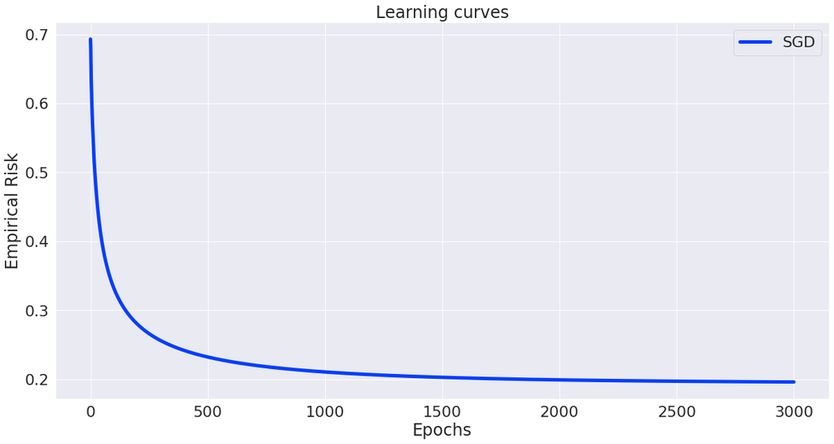

```python
clf_sgd = LogisticRegression(solver='sgd', l2=0.01, max_iter=3000)
clf_sgd.fit(A_train, b_train)

learning_curve(SGD=clf_sgd)
```

# Variance Reduced Stochastic Gradient Descent

The random selection of the gradient introduces variance into the gradient descent algorithm. This is one of the reasons SGD converges so slowly and requires a very small step size to converge (it can fail to converge for step sizes larger than $\frac{1}{k}$). Therefore it is desirable for a stochastic gradient algorithm to take into account the variance introduced by the randomness and somehow manage it.

The Stochastic Avergage Gradient Amelior\'e (SAGA) and Stochastic Variance Reduced Gradient (SVRG) methods are two popular methods to perform SGD while reducing the variance.

These methods both make use of the finite sum stucture in problems of the form: $$ \text{min} f(x) : f(x) = \sum_{i = 1}^n f_i(x)$$

These methods use control variates to reduce the variance introduced by taking $f_{i}^{\prime}(x)$ as an estimate of the full gradient $f^{\prime}(x).$ "Control variates are a classical technique for reducing the variance of a stochastic quantity without introducing bias. Say we have some random variable $X .$ Although we could use $X$ as an estimate of $E[X]=\bar{X},$ we can often do better through the use of a control variate $Y .$ If $Y$ is a random variable correlated with $X \text { (i.e. } \operatorname{Cov}[X, Y]>0),$ then we can estimate $\bar{X}$ with the quantity [ Z=X-Y+E[Y] ] This estimate is unbiased since $-Y$ cancels with $E[Y]$ when taking expectations, leaving $E[Z]=$ $E[X] .$ As long as $\operatorname{Var}[Y] \leq 2 \operatorname{Cov}[X, Y],$ the variance of $Z$ is lower than that of $X$"

Note that this makes them unsuitable for optimization in deep learning (cf Defazio and Bottou, in NIPS 2019: http://papers.nips.cc/paper/8452-on-the-ineffectiveness-of-variance-reduced-optimization-for-deep-learning.pdf)

# SAGA (Stochastic Average Gradient "Amélioré")

SAGA starts by computing a single batch gradient, then at iteration k, the following update is executed:

$$ \begin{cases} i \textrm{ chosen randomly in } \{1...n\}\\ x_{k+1} \leftarrow x_{k} - \gamma_k\big(\nabla f_i(x_k) - \alpha_i + \bar{\alpha}\big) \\ \alpha_i \leftarrow \nabla f_i(x) \end{cases} $$

where $(\alpha_j)_{j=1}^n$ are gradients evaluated at previous iterates and $\bar{\alpha}=\frac{1}{n}\sum^n_{j=1}\alpha_j$.

**Question:**

- What stepsize $\gamma_k$ ensures the convergence of this algorithm and under what assumptions?
- Complete **TODO (6)**
- Add your code to **\lib\solvers.py**.

```python
def SAGA(x0, grad, prox, max_iter, n, L, mu):
    x = np.copy(x0)
    x_tab = np.copy(x)
    grad_fi_tab = np.zeros((n, np.shape(x0)[0]))

    step = (1/2)*(mu*n+L)
    for i in range(n):
        grad_fi_tab[i,:] = grad(x,i)

    for k in range(max_iter):
        i = np.random.randint(n)
        cur_grad = grad(x,i)
        w = x - step * (cur_grad - grad_fi_tab[i,:] + cesaro(grad_fi_tab))
        x = prox(w , step)
        if k%n == 0:
            x_tab = np.vstack((x_tab,x))
        grad_fi_tab[i,:] = cur_grad

    return x,x_tab
```

**Question:** Run the code below to test your code.

```
3000
False
```

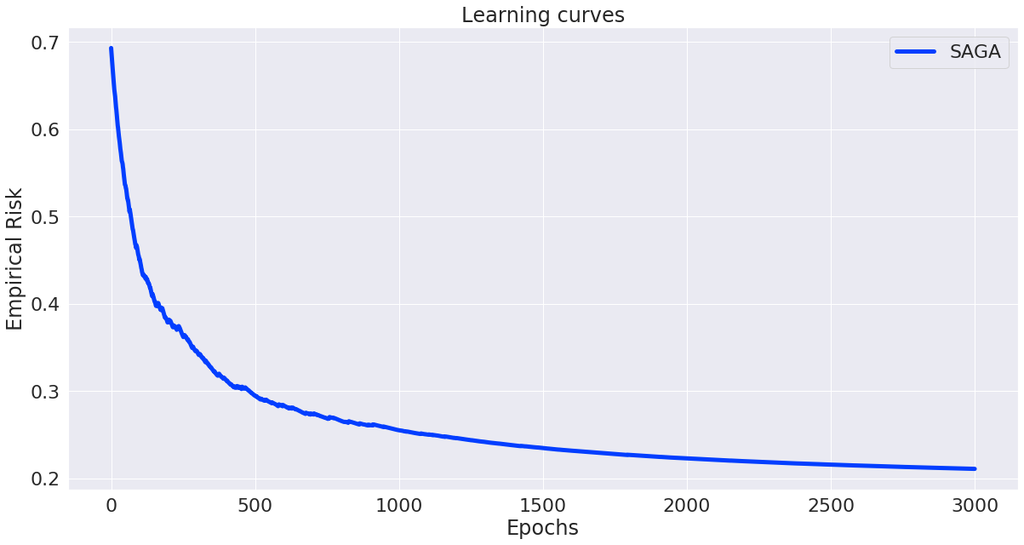

```python
clf_saga = LogisticRegression(solver='saga', l2=0.01, max_iter=3000)

clf_saga.fit(A_train, b_train)

learning_curve(SAGA=clf_saga)
```

# SVRG (Stochastic Variance Reduced Gradient)

At iteration k of the SVRG algorithm, we perform the following:

$$ \begin{cases} \textrm{Compute the batch gradient } \nabla f(x_k)\\ \textrm{Initialise }y_0 = x_k\\ \textrm{for m in 0...M-1: } \begin{cases} i \textrm{ chosen randomly in } \{1...n\} \\ y_{m+1} \leftarrow y_{m} - \gamma_k\big(\nabla f_i(y_m) - \nabla f_i(x_k) + \nabla f(x_k)) \end{cases}\\ x_{k+1} \leftarrow y_{M} \end{cases} $$

**Question:**

- What stepsize $\gamma_k$ ensures the convergence of this algorithm and under what assumptions?
- Complete **TODO (7)**
- Add your code to **\lib\solvers.py**.

The authors of SVRG (Johnson and Zhang) prove that any stepsize $\gamma$ that satisfies: $$ \frac{1}{\gamma \eta(1-2 L \eta) m}+\frac{2 L \eta}{1-2 L \eta}<1 $$ where m is the number of iterations per epoch. If we take $\eta = \frac{1}{L}$ the above equation is satified.

```python
def SVRG(x0, grad, prox, max_iter, n, L, mu):
    x = np.copy(x0)
    x_tab = np.copy(x)
    gamma = 1/L
    update = x0.size

    assert(1/(gamma*mu*(1-2*L*gamma)*update) + (2*L*gamma)/(1-2*L*gamma) < 1)

    for k in range(max_iter):

        full_grad = grad(x)

        y = x

        s = 0

        for j in range (1,update):

            i = np.random.randint(1,n) # choose uniformly i in 1, ..., nbr of realisation = final_grades.size

            v = (grad(y,i) - grad(x,i)) + full_grad

            y = prox(y - gamma*v , gamma)

            s += y/(update-1)

        if k%n == 0:
            x_tab = np.vstack((x_tab,x))

        x_tab = np.vstack((x_tab,x))
    return x,x_tab
```

**Question:** Run the code below to test your code.

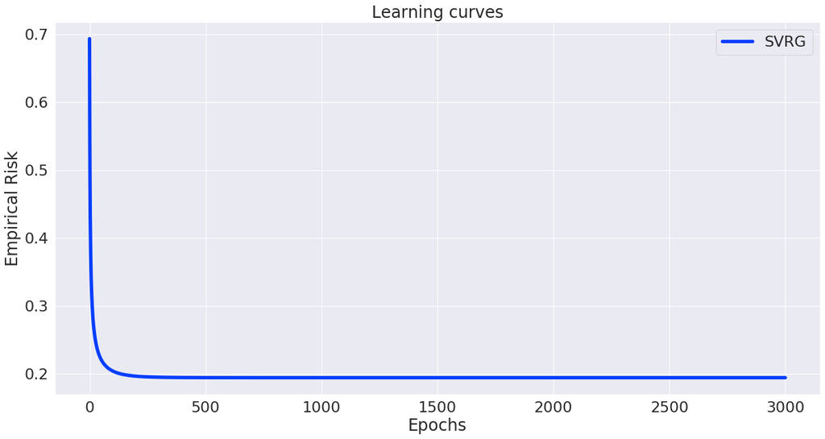

```python
clf_svrg = LogisticRegression(solver='svrg', l2=0.01, max_iter=3000)
clf_svrg.fit(A_train, b_train)

learning_curve(SVRG=clf_svrg)
```

# Comparison

**Question:** Run the code below to compare all the methods you've implemented.

```python
epochs = 50
n = len(b_train)

clf_gd   = LogisticRegression(solver='gd', l2=0.01, max_iter=n*epochs)
clf_sgd  = LogisticRegression(solver='sgd', l2=0.01, max_iter=n*epochs)
clf_saga = LogisticRegression(solver='saga', l2=0.01, max_iter=n*epochs)
clf_svrg = LogisticRegression(solver='svrg', l2=0.01, max_iter=n*epochs)

clf_gd.fit(A_train, b_train)
clf_sgd.fit(A_train, b_train)
clf_saga.fit(A_train, b_train)
clf_svrg.fit(A_train, b_train)
```

```
14800
False
```

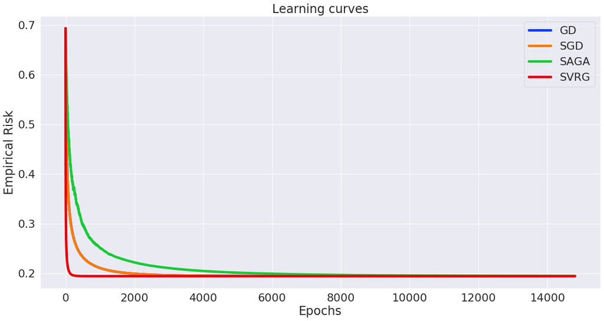

```
gd:	Accuracy on training set: 94.3%
	Accuracy on testing set:  96.0%
sgd:	Accuracy on training set: 94.3%
	Accuracy on testing set:  96.0%
saga:	Accuracy on training set: 94.3%
	Accuracy on testing set:  96.0%
svrg:	Accuracy on training set: 94.3%
	Accuracy on testing set:  96.0%
```

```python
learning_curve(GD=clf_gd, SGD=clf_sgd, SAGA=clf_saga, SVRG=clf_svrg)

for clf, name in zip([clf_gd, clf_sgd, clf_saga, clf_svrg], ['gd', 'sgd', 'saga', 'svrg']):
    print(name + ':' \
          + "\tAccuracy on training set: {0:0.1f}%".format(100*clf.score(A_train, b_train)))
    print("\tAccuracy on testing set:  {0:0.1f}%".format(100*clf.score(A_test, b_test)))
```

# IV. Regularization

**Question:**

- Rewrite the empirical risk minimization objective with both $L_1$ and $L_2$ regularization (with coefficients $l_1$ and $l_2$).
- Is this objective $\mu$-strongly convex, $L$-smooth, differentiable?
- Complete the **TODO (8)** to account for the new term in the objective.
- Add your code to **lib/linear_model.py**.

> **Answer:** \begin{align*} \min_{x\in\mathbb{R}^d } F(x) := \underbrace{ \frac{1}{m} \sum_{i=1}^m \log( 1+\exp(-b_i \langle a_i,x \rangle) ) + \frac{\lambda_2}{2} \|x\|_2^2}_{f(x)} + \underbrace{\lambda_1 \|x\|_1 }_{g(x)}. \end{align*}

> This objective is still $\mu$ strongly convex. However, it is no longer smooth or differentiable everywhere (due to the $\ell_1$ regularzation

```
self._empirical_risk = lambda x: sum(self._logistic_loss(A, b, x))/n \
                                 + self.l2/2.0 * np.linalg.norm(x,2) \
                                 + self.l1*np.linalg.norm(x,1)
```

The minimization algorithms we've implemented have a slow rate of convergence for this new objective function. We will therefore use *proximal* variations of these algorithms.

**Question:** Using the $\textrm{prox}_{l_1 \|\cdot\|_1}$ operator, write down the $k^{th}$ step of proximal GD, proximal SGD, proximal SAGA, and proximal SVRG.

> **Answer:** $x_{k+1}=\operatorname{prox}_{\gamma g}\left(x_{k}-\gamma \nabla f\left(x_{k}\right)\right)$

**Question:**

- Give a closed-form expression of $\textrm{prox}_{l_1 \|\cdot\|_1}$
- Complete **TODO (9)** (note that you can access the $l_1$ coefficient using **self.l1**).
- Add your code to **\lib\linear_model.py**.

> **Answer:**

> $ \textrm{prox}_{l_1 \|\cdot\|_1} =\left\{ \begin{array}{ll} x[i] + \ell_1 * \gamma, \text{ if } x[i] < -\ell_1 * \gamma\\ x[i] - \ell_1 * \gamma, \text{ if } x[i] > -\ell_1 * \gamma \end{array} \right. $

```python
def prox(x, stepsize):
    p = np.zeros(n)
    for i in range(n):
        if x[i] < - lam1*stepsize:
            p[i] = x[i] + lam1*stepsize
        if x[i] > lam1*stepsize:
            p[i] = x[i] - lam1*stepsize
    return p
```

**Question:**

- Add **prox** to the attributes of the solvers (both in the call to **self.solver** in **/lib/linear_model.py** and in **/lib/solvers.py**) as follows:  
  solver(x0, grad, **prox**, self.max_iter, n, L, mu)
- Add a proximal step to all the algorithms in **/lib/solvers.py**.
- Paste one of these algorithms in the cell bellow.

```python
def GD(x0, grad, prox, max_iter, n, L, mu):
    stepsize  = 1/L
    for k in range(max_iter):
        x_prev = x
        gradf = grad(x)
        x = prox(x - step*gradf , step)

        x_tab = np.vstack((x_tab,x))

    return x, x_tab
```

**Question:** If your proximal gradient descent is correctly implemented, the following cell will plot the support of the solution for various values of $l_1$.

- Interpret the plot and explain what can $L_1$ regularization be used for.

> **Answer:** $\ell_1$ regularization can be used for sparsification of the objective.

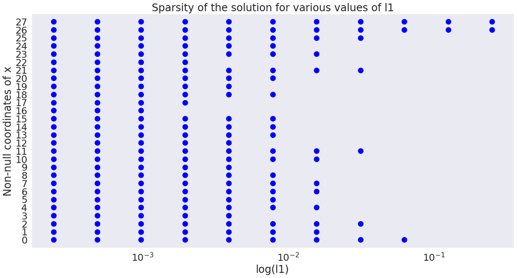

```python
from lib.visuals import l1_regularization_plot

clf = lambda l1: LogisticRegression(solver='gd', l1=l1, l2=0.1, max_iter=1000)

l1_regularization_plot(clf, A_train, b_train)
```

**Question:** The following cell will plot the value of the coordinates of the solution for various values of $l_2$.

- Interpret the plot and explain what can $L_2$ regularization be used for.

> **Answer:** $\ell_2$ regularization can be used to convexify the objective. In the plot below, we also note that $\ell_2$ regularization shifts the regression fit, potentially avoiding overfitting.

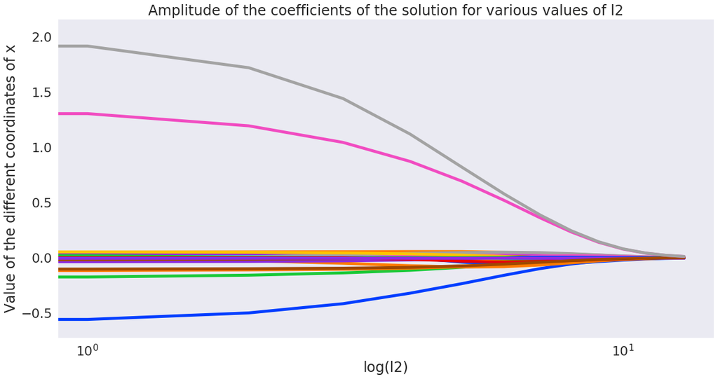

```python
from lib.visuals import l2_regularization_plot

clf = lambda l2: LogisticRegression(solver='gd', l1=0.01, l2=l2, max_iter=1000)

l2_regularization_plot(clf, A_train, b_train)
```

# Conclusions

The most well known variance reduced optimization techniques are SAGA and SVRG (and their proximal variants). SAGA is memory expensive and SVRG is (relatively) compute expensive as full gradients need to be recalculated every epoch. Therefore SAGA and may be unattractive for large scale learning problems.

# When to stop

In problems harder than logistic regression on the student dataset, we may have to perform many more iterations for the objective to reach its minimum or local minimum. Therefore it would be useful to have some other criterion than the maximum number of iterations to stop the algorithm.

In a convex problem, one could stop when the value of the gradient is close to zero. However, in any more general, non-convex setting this will fail as the gradient is close to zero at any local minimum.

A naive method consists in evalutating the difference $|x_{k+1} - x_{k}|$, and stopping once $|x_{k+1} - x_{k}| \leq \epsilon$. However, when we use a stochastic method to minimize the loss function, the difference $\epsilon = |x_{k+1} - x_{k}|$ is not a reliable measure of convergence because $x_{k}$ and $x_{k+1}$ comprise an element of randomness. Thus, $\epsilon$ could increase for some iterations, while the algorithm is still converging. We would like to find a stopping criterion that accurately measures the progress (or lack therof) of our algorithm.

Another way to decide whether the algorithm has converged is to use the duality theorem. Let $P$ denote the primal, $D$, the dual. $ P = \textrm{min}_{x\in \mathbb{R}^d} \ f(x)$ $ D = \textrm{max}_{y\in \mathbb{R}^d} \ g(y)$ The strong duality theorem states that if optima for the primal ($P^*$ ) and dual ($D^*$) exist, then $P^* = D^*$

Therefore if $|P - D| < tol $, that is if the duality gap is small enough, we can say that the algorithm has converged.

Thomas Minka (A comparison of numerical optimizers for logistic regression, 2003) proposes a dual formulation for logistic regression inspired by that of Jaakkola & Haussler (1999).

However the duality gap criterion may be unsuitable for stochastic algorithms for the same reasons as evaluating the difference between iterates: due to the randomness in the stochastic algorithms.

Therefore, instead of comparing $x_{k}$ and $ x_{k-1}$ we compare $x_{k}$ to all previous $x_{i}$, $i = 1, ..., k-1$. An easy way to do this is to look at whether $x_{k}$ is close to its Cesàro mean.
Let $(a_n)_{n=1}^\infty$ be a sequence, and let $s_k = a_1 + \cdots + a_k = \sum_{n=1}^k a_n$ be its partial sum.
Then the **Cesàro mean**, which is the mean of the $n$ first partial sums of a Cesàro sum is $$ c_{n} = \frac{1}{n} \sum_{k=1}^{n}{s_k} = \frac{a_{1} + \cdots + a_{n}}{n} $$

The **Cesàro lemma** states that: If $(a_{n})$ converges to $l \in \mathbb{R}$  
Then, its Cesàro sum $\lim_{n\to\infty} c_{n} $ also converges to $l$.

This means that if our sequence of $x_{k}$ converges (which it does), it will converge to it's Cesàro mean. Our new stopping criterion is thus:  
$\epsilon_{C} = |x_{k+1} - (c_{k})| < tol$ where $tol$ is some given precision.

Let's test this for our gradient decent algorithms:

In order to see whether the algorithms will converge, we add a parameter 'stop' to all of the gradient algorithms that determines whether or not they should stop. This is implemented in linear_model.py and in the solvers

Here is an example of SAGA with the new parameters

```python
def SAGA(x0, grad, prox, max_iter, n, L, mu, stop, toprint, PREC):
    x = np.copy(x0)
    x_tab = np.copy(x)
    grad_fi_tab = np.zeros((n, np.shape(x0)[0]))

    #step = (1/2)*(mu*n+L)
    step = 1/(3*L)
    for i in range(n):
        grad_fi_tab[i,:] = grad(x,i)

    for k in range(max_iter):

        x_prev = x
        i = np.random.randint(n)
        cur_grad = grad(x,i)
        w = x - step * (cur_grad - grad_fi_tab[i,:] + cesaro(grad_fi_tab))
        x = prox(w , step)
        if k%n == 0:
            x_tab = np.vstack((x_tab,x))

        grad_fi_tab[i,:] = cur_grad

        if stop & np.allclose(x, cesaro(x_tab[:-1]), atol=PREC):
            print("Reached Stopping Criterion")
            break

    return x,x_tab
```

```python
clf_gd   = LogisticRegression(solver='gd', l2=0.01, max_iter=1000,  stop=True, toprint=True)
clf_sgd  = LogisticRegression(solver='sgd', l2=0.01, max_iter=1000, stop=True, toprint=True)
clf_saga = LogisticRegression(solver='saga', l2=0.01, max_iter=1000,stop=True, toprint=True)
clf_svrg = LogisticRegression(solver='svrg', l2=0.01, max_iter=1000,stop=True, toprint=True)

clf_gd.fit(A_train, b_train)
clf_sgd.fit(A_train, b_train)
clf_saga.fit(A_train, b_train)
clf_svrg.fit(A_train, b_train)
```

```
------------------------------------
 gradient descent
------------------------------------
START    -- stepsize = 0.040235947301774495
Reached Stopping Criterion
FINISHED -- 683 iterations / 0.339099s


------------------------------------
 Stochastic gradient algorithm
------------------------------------
START    -- stepsize = 0.040235947301774495
FINISHED -- 999 iterations / 0.627612s


------------------------------------
 SAGA algorithm
------------------------------------
START    -- stepsize = 0.01341198243392483
FINISHED -- 999 iterations / 0.211669s


------------------------------------
 SVRG algorithm
------------------------------------
START    -- stepsize = 0.040235947301774495
FINISHED -- 999 iterations / 3.016352s
```

For 1000 iterations is the SAGA is fastest followed by the Proximal gradient algorithm and SGD. The proximal algorithm ought to be the slowest of all of them, because it computes the full gradient at each timestep, but in practice this is not the case because it hits its stopping criterion wheras the stochastic algorithms do not.

Also note that the SAGA is roughly 10 times faster than SVRG, that is because it saves precomputed iterates, resulting in a speed increase.